# 2.04-Singly-Linked-Lists

### Topics Covered

- Introduction
- Append
- Prepend
- Pop Left
- Pop Right
- Remove
- Reverse
- Memory Allocation
- Table of Complexity Comparison
- Real-Life Applications of Singly Linked Lists

### Introduction to Singly Linked Lists

Although this is one of the most popular data structures that comes out of the box in most programming languages, when we got into the details of its technical implementation, we saw that it had a few limitations.

- The dynamic arrays require memory reallocation whenever we increase them past a specific limit, and that can be computationally expensive.
- In the case of static arrays, we have to know their maximum size when defining them, which can be a problem since we don't always know how many elements we'll end up having
- Also because of the way it's stored in memory Adding and removing an item from the beginning or from inside an array will cause all the other items to be shifted, which again will require extra computing time.

This is where the linked list data structure comes into play. Its design naturally overcomes these limitations, and the way it achieves this is by changing how elements are stored in memory.

- A linked list representation of the same collection of numbers will look something like this. Each element will have its own container. And each element will have a connection to the next one after it
- It's important to note that each element will have only one link to the next element.
- So when representing this in code, we'll have to create a container with two pieces, one for the information we want to store (orange) and one for the link which will visually represent as this arrow (white)
- And using this arrow, we can connect the current item to the next one and then the next one, and so on
- The last element will also be one of these containers that will contain an arrow. But what will it point to? Logically, if it's the last element, it means that it doesn't point to any other value. It points to, well, nothing. And in Python we represent the concept of nothing with the none value.

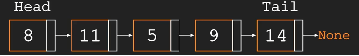

If we have a look at the design of the two lists, we can immediately see a couple of differences.

- The first one is that in the **linked list**, each element is wrapped in its own container, as opposed to the regular array, where the array itself acts like the container for all the items.
- The second one at the bottom (**Regular List**) is the indexing of the regular array. Each element can be accessed by its index, something we can't do in a linked list.

And that's the theory behind them.

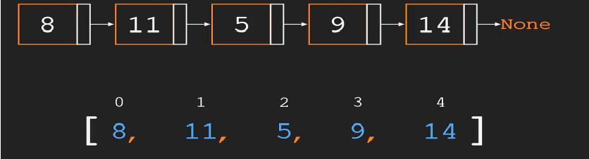

So as we just saw, linked lists are a collection of nodes that contain our data. So if we were to represent that in code we need to create a node container which will be initialized with two members.

1. The value &
2. Next pointer

In Python, containers are usually built with **classes**, which is actually something we'll use for other data structures as well, so you need a basic understanding of them going forward in the course. So this value property will contain the actual information we want to store in the list.

In our example there were numbers, but it can be anything Strings, custom objects, lists or any other data structure. We'll pass it as an argument in the init method, because we want to be able to directly create our node objects with this value. The other property of our node class is the pointer to the next node, which will simply call next.

This one is crucial for the implementation of the linked list. It's how we keep the list together and how we can travel forward from one element to another. We won't give it any value to start with. We'll initialize it as none and then assign the value accordingly when we create the node.

**Why Classes Are Needed for Linked Lists ?**

1. Encapsulation of Data + Behavior
- A linked list isn’t just data; it’s also the operations you perform on it (append, delete, search, traverse).
- Using a class lets you bundle the nodes (data) and the methods (behavior) together in one structure.
2. Node Representation
- Each element in a linked list is a Node (with value and next pointer).
- A Node class makes it easy to define this structure once and reuse it:

```python
class Node:
    def __init__(self, value):
        self.value = value
        self.next = None
```

3. LinkedList Management
- The linked list itself needs to track:
- head (first node)
- tail (last node)
- _length (number of nodes)
- A LinkedList class keeps these attributes organized and provides methods like:
- append(value)
- insert(index, value)
- delete(value)
- **len**() for length
4. Reusability & Modularity
- With classes, you can create multiple linked lists independently:

```python
list1 = LinkedList()
list2 = LinkedList()
# Each list manages its own nodes without interfering with others.
```

5. Cleaner Code & Abstraction
- Without classes, you’d juggle raw dictionaries or tuples for nodes and manually handle pointers — messy and error-prone.
- Classes abstract away the details, so you can just call mylist.append(10) instead of writing pointer logic every time.

```python
# Example Structure
class Node:
    def __init__(self, value):
        self.value = value
        self.next = None

class LinkedList:
    def __init__(self):
        self.head = None
        self.tail = None
        self._length = 0

    def append(self, value):
        new_node = Node(value)
        if not self._length:
            self.head = self.tail = new_node
        else:
            self.tail.next = new_node
            self.tail = new_node
        self._length += 1
        return self
```

🌟 Key Takeaway

We use classes for linked lists because they:

- Organize nodes and operations together
- Provide abstraction (hide pointer details)
- Enable reusability and modularity
- Make the code cleaner, safer, and easier to extend

Let's now define our singly linked list class. We mentioned that we want to keep track of the first and last elements of the list, and we called them **head** and **tail**. So we need to create these two properties which will also be set to **none**.

We don't want to give them any starting values. We want the list to be empty when initialized. Both the head and the tail will eventually be some node objects we just defined up here.

One last property I'd like to add and that is the length.We'll set its starting value to zero and then increase and decrease it as we add or remove nodes. The length is not mandatory, but it will make our lives easier with certain methods.

```python
class SinglyLinkedList:
    def __init__(self):
        self.head = None
        self.tail = None
        self._length = 0
```

**Why do we have "_length" and not just "length"**

- In Python, a leading underscore (like _length) signals “internal use” or “private”.
- It tells other programmers:“This attribute is part of the internal mechanics of the class. You shouldn’t touch it directly unless you know what you’re doing

🔹 Analogy

Think of like the engine inside a car

- You can open the hood and mess with it, but you’re supposed to drive using the steering wheel and pedals (the public methods
- The underscore is the “hood closed” sign..

**Why are we creating 2 seperate Classes (Node & SinglyLinkedList) and not have all the properties under 1 single class?**

1. **Node** class
- Represents a single element in the list.
- Stores value and a pointer (next) to the next node.
- It’s the building block.
2. **SinglyLinkedList** class
- Manages the collection of nodes.
- Keeps track of the head, tail, and _length.
- Provides operations like append, delete, find, etc.

This separation follows the principle of single responsibility:

- A Node only knows about itself and its neighbor.
- The SinglyLinkedList knows about the whole chain.

**Analogy**

Imagine a train:

- Each carriage (Node) has passengers and a link to the next carriage.
- The train (SinglyLinkedList) knows where the first carriage is (head), where the last one is (tail), and how many carriages there are (length).

If you tried to make each carriage also responsible for being the train, you’d end up duplicating information and confusing responsibilities.

🔹 Bottom line

- Separate classes → clean, modular, reusable.
- Single class → possible, but messy and unscalable.

That’s why in data structure design, we almost always split them.